# Tarea_student

Javier

2022-11-04

## Objetivo de la práctica

Trabajar el dataset “student”, explorando y analizando patrones

## Cargamos nuestro dataset

read.csv() y read.csv2() * **sep**=“,” por defecto en read.csv * **sep**=“;” por defecto en read.csv2 * **header**=TRUE por defecto en ambos

```r
getwd()
con <- file("student-por.csv","r")
studentPor <- read.csv2(con)
close(con)
head(studentPor[,1:10])
```

[output not shown]

## Igual proceso para studentMat usando read.table

```r
library(knitr)
getwd()
studentMat <- read.table("student-mat.csv", row.names=NULL, sep=";", header=TRUE)
kable(head(studentMat[,1:5]))
```

[output not shown]

## Ejercicio 1

Crea un nuevo data.frame de nombre “studentMatPor”

que tenga los 382 estudiantes que han estudiado ambas materias.

Esos estudiantes se identifican por tener los mismos valores

en los data.frames “studentMat” y “studentPor”

para estos atributos:

“school”,“sex”,“age”,“address”,“famsize”,“Pstatus”,“Medu”,“Fedu”, “Mjob”,“Fjob”,reason”,“nursery”,“internet”

```r
studentMatPor <- merge(studentMat,studentPor,
                       by=c("school","sex","age",
                            "address","famsize",
                            "Pstatus","Medu",
                            "Fedu","Mjob",
                            "Fjob","reason",
                            "nursery","internet"),
                       all=FALSE,
                       suffixes=c("mat","por"))
dim(studentMatPor)[1]
```

[1] 382

## Ejercicio 2

Crea un data.frame de nombre “studentMatPor2”,

que sea copia de “studentMatPor”,

pero ordenado en primer lugar **por orden creciente** de la variable “age”,

y en segundo lugar **por orden también creciente** de la variable “mjob”

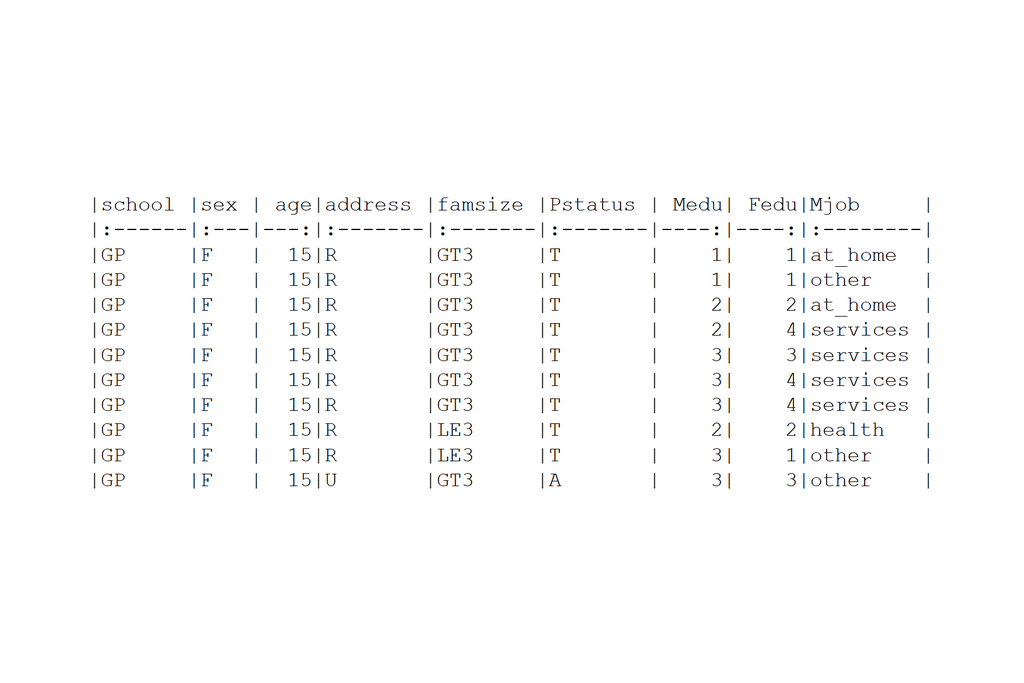

```r
studentMatPor [1:10,1:9]
```

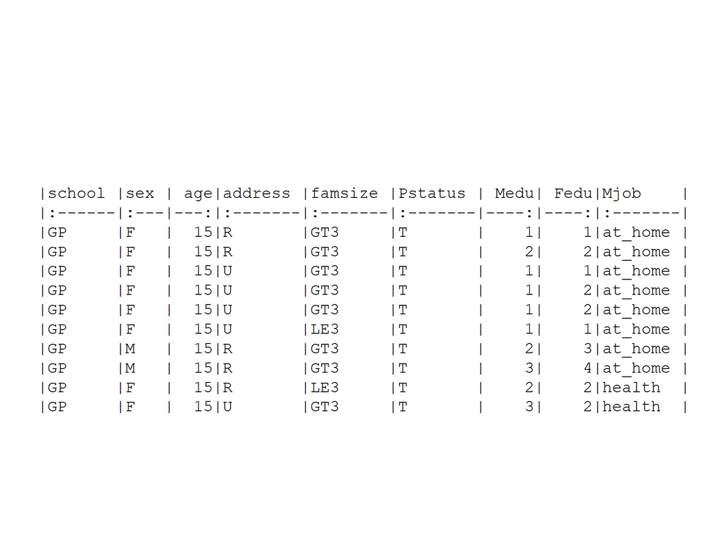

```r
studentMatPor2 <- studentMatPor[order(
        studentMatPor[,3],
        xtfrm(studentMatPor[,9])), ]
studentMatPor2[1:10,1:9]
```

## Ejercicio 3

Ordenar dataframe “studentMatPor2” del ejercicio anterior:

**en orden decreciente de la variable “age”**,

**en orden decreciente de la variable “famsize”**.

famsize: “LE3” - less or equal to 3 y “GT3” - greater than 3. Orden decreciente primero las GT3

```r
studentMatPor2 <- studentMatPor[order(
        -studentMatPor[,3],
        xtfrm(studentMatPor[,5])), ]
row.names(studentMatPor2) <- NULL
studentMatPor2[1:20,1:5]
```

[output not shown]

## Ejercicio 4

Entre los estudiantes de matemáticas: ¿quiénes suman en total más ausencias, los que pagan extraescolares, o los que no?

```r
tapply(studentMat$absences,studentMat$paid,sum)
```

[output not shown]

## Ejercicio 5

Calcular la media de graduación final de los alumnos de matemáticas, por cada posible profesión paterna.

```r
divideFjob <- split(studentMat, studentMat$Fjob)
sapply(divideFjob, function(x) mean(x$G3))
```

[output not shown]